# Time Series Model for Vehicle Miles Traveled Using Python

### March 25, 2020

Template Credit: Adapted from a template made available by Dr. Jason Brownlee of Machine Learning Mastery. https://machinelearningmastery.com/

SUMMARY: The purpose of this project is to construct a time series prediction model and document the end-to-end steps using a template. The Vehicle Miles Traveled dataset is a time series situation where we are trying to forecast future outcomes based on past data points.

CONCLUSION: For this dataset, the chosen ARIMA model achieved a satisfactory result and should be considered for further modeling.

Dataset Used: Vehicle Miles Traveled

Dataset ML Model: Time series forecast with numerical attributes

Dataset Reference: https://fred.stlouisfed.org/series/VMT

The project aims to touch on the following areas:

- Document a predictive modeling problem end-to-end
- Explore data cleaning and transformation options
- Explore various algorithms for baselining the model performance
- Explore tuning techniques for improving the model performance

A time series predictive modeling project genrally can be broken down into about five major tasks:

1. Define Problem and Acquire Data
2. Inspect and Explore Data
3. Clean and Pre-Process Data
4. Fit and Evaluate Models
5. Finalize Model

## Section 1. Define Problem and Acquire Data

### 1.a) Load Libraries

```python
import numpy as np
import pandas as pd
import matplotlib.pyplot as plt
import seaborn as sns
import os
import math
import smtplib
import pmdarima as pm
import pandas_datareader.data as web
from datetime import datetime
from email.message import EmailMessage
from sklearn.metrics import mean_squared_error
from statsmodels.tsa.statespace.sarimax import SARIMAX
from statsmodels.tsa.stattools import adfuller
from statsmodels.tsa.seasonal import seasonal_decompose
from statsmodels.graphics.tsaplots import plot_acf
from statsmodels.graphics.tsaplots import plot_pacf
```

### 1.b) Set up the controlling parameters and functions

```python
# Create the random seed number for reproducible results
seedNum = 888

# Set up the number of CPU cores available for multi-thread processing
n_jobs = -1

# Set up the verbose flag to print detailed messages for debugging (setting True will activate!)
verbose = False

# Set up the flag to stop sending progress emails (setting to True will send status emails!)
notifyStatus = False
```

```python
# Set up the email notification function
def email_notify(msg_text):
    sender = os.environ.get('MAIL_SENDER')
    receiver = os.environ.get('MAIL_RECEIVER')
    gateway = os.environ.get('SMTP_GATEWAY')
    smtpuser = os.environ.get('SMTP_USERNAME')
    password = os.environ.get('SMTP_PASSWORD')
    if sender==None or receiver==None or gateway==None or smtpuser==None or password==None:
        sys.exit("Incomplete email setup info. Script Processing Aborted!!!")
    msg = EmailMessage()
    msg.set_content(msg_text)
    msg['Subject'] = 'Notification from Python ARIMA Time Series Script'
    msg['From'] = sender
    msg['To'] = receiver
    server = smtplib.SMTP(gateway, 587)
    server.starttls()
    server.login(smtpuser, password)
    server.send_message(msg)
    server.quit()
```

```python
if (notifyStatus): email_notify("Library and Data Loading has begun! "+datetime.now().strftime('%a %B %d, %Y %I:%M:%S %p'))
```

### 1.c) Acquire and Load the Data

```python
startTimeScript = datetime.now()
```

```python
# load the dataset and the necessary data structure
# time_series = pd.read_csv('https://dainesanalytics.com/datasets/time-series-data-library/tsdl200.csv', index_col='idx', parse_dates=True)

# Load the dataset from the Federal Reserve Bank's FRED Database
starting = datetime(2000, 1, 1)
ending = datetime.now()
fred_data = 'VMT'
time_series = web.DataReader(fred_data, 'fred', starting, ending)
time_series.rename(columns={fred_data: 'value'}, inplace=True)

# Sample code for subsetting the time-series data
# time_series = original_series['1986':'1990']
```

```python
target_col = time_series.columns[0]
lower_bound = 'lower ' + target_col
upper_bound = 'upper ' + target_col
print('The target column of the time series is:', target_col)
print('The forecast boundary columns are:', lower_bound, '&', upper_bound)
```

```
The target column of the time series is: value
The forecast boundary columns are: lower value & upper value
```

```python
time_series.info()
```

```
<class 'pandas.core.frame.DataFrame'>
DatetimeIndex: 239 entries, 2000-01-01 to 2019-11-01
Data columns (total 1 columns):
 #   Column  Non-Null Count  Dtype
---  ------  --------------  -----
 0   value   239 non-null    int64
dtypes: int64(1)
memory usage: 3.7 KB
```

```python
time_series.head(10)
```

| DATE | value |
| --- | --- |
| 2000-01-01 | 203442 |
| 2000-02-01 | 199261 |
| 2000-03-01 | 232490 |
| 2000-04-01 | 227698 |
| 2000-05-01 | 242501 |
| 2000-06-01 | 242963 |
| 2000-07-01 | 245140 |
| 2000-08-01 | 247832 |
| 2000-09-01 | 227899 |
| 2000-10-01 | 236491 |

```python
time_series.tail(10)
```

| DATE | value |
| --- | --- |
| 2019-02-01 | 226799 |
| 2019-03-01 | 271668 |
| 2019-04-01 | 281646 |
| 2019-05-01 | 286269 |
| 2019-06-01 | 281345 |
| 2019-07-01 | 295744 |
| 2019-08-01 | 286857 |
| 2019-09-01 | 271986 |
| 2019-10-01 | 284203 |
| 2019-11-01 | 260333 |

```python
if (notifyStatus): email_notify("Library and Data Loading completed! "+datetime.now().strftime('%a %B %d, %Y %I:%M:%S %p'))
```

## Section 2. Inspect and Explore Data

```python
if (notifyStatus): email_notify("Data Inspection and Exploration has begun! "+datetime.now().strftime('%a %B %d, %Y %I:%M:%S %p'))
```

### 2.a) Summary Statistics of the Time Series Data

Summary statistics provide a quick look at the limits of observed values. It can help to get a quick idea of what we are working with.

```python
# Summary statistics of time series
print(time_series.describe())
```

```
               value
count     239.000000
mean   250353.799163
std     19193.665274
min    199261.000000
25%    238788.000000
50%    252271.000000
75%    263440.000000
max    295744.000000
```

### 2.b) Line Plot of the Time Series Data

A line plot of a time series can provide a lot of insight into the problem. Some observations from the plot can include:

- Whether the trend appears to be level around the mean
- Whether there appear to be any obvious outliers

The ARIMA(p,d,q) model requires three parameters and assumes that we are working with a stationary time series.

The ADF results should show that the test statistic value is smaller than the critical value at 5% if the time series is stationary. This suggests that we can reject the null hypothesis (i.e. a low probability that the result is a statistical fluke).

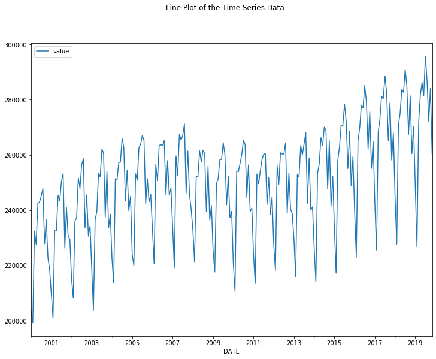

```python
# Line plots of time series
fig, ax = plt.subplots(figsize=(12,9))
fig.suptitle('Line Plot of the Time Series Data')
time_series.plot(ax=ax)
plt.show()
```

### 2.c) Histogram and Density Plots of the Time Series Data

Reviewing plots of the density of observations can provide further insight into the structure of the data. Some observations from the plots can include:

- Whether the distribution is Gaussian
- Whether the distribution has a long tail and may suggest the need for data transformation

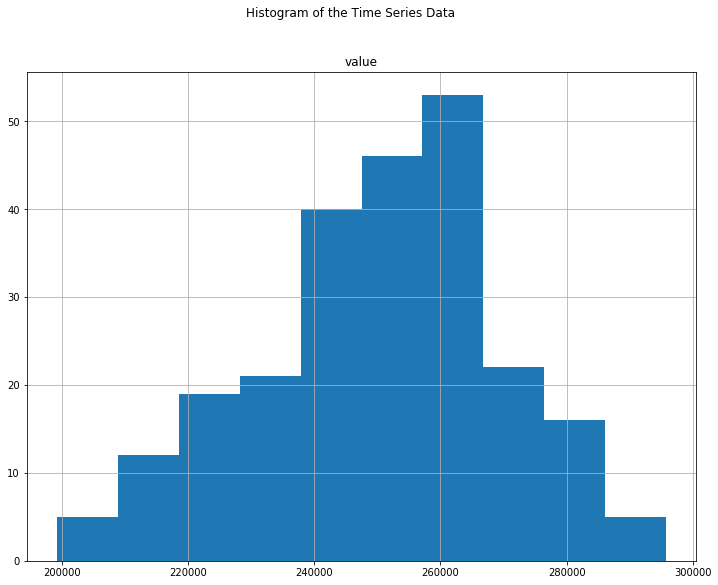

```python
# Line plots of time series
fig, ax = plt.subplots(figsize=(12,9))
fig.suptitle('Histogram of the Time Series Data')
time_series.hist(ax=ax)
plt.show()
```

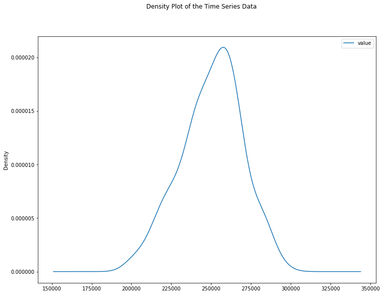

```python
# Line plots of time series
fig, ax = plt.subplots(figsize=(12,9))
fig.suptitle('Density Plot of the Time Series Data')
time_series.plot(kind='kde', ax=ax)
plt.show()
```

### 2.d) Box and Whisker Plots of the Time Series Data

We can group or aggregate the data and get a better idea of the spread of observations. Some observations from reviewing the plot can include:

- Whether the median values for each grouping shows any significant trend
- Whether the spread, or middle 50% of the data, shows any significant variability
- Whether there are outliers in some grouping

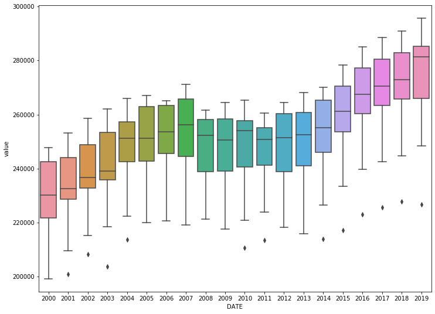

```python
# boxplots of time series
fig, ax = plt.subplots(figsize=(12,9))
squeezed = time_series.squeeze()
sns.boxplot(squeezed.index.year, squeezed, ax=ax)
plt.show()
```

```python
if (notifyStatus): email_notify("Data Inspection and Exploration completed! "+datetime.now().strftime('%a %B %d, %Y %I:%M:%S %p'))
```

## Section 3. Data Transformation and Stationarity Tests

```python
if (notifyStatus): email_notify("Data Cleaning and Pre-Processing has begun! "+datetime.now().strftime('%a %B %d, %Y %I:%M:%S %p'))
```

### Section 3.a) Data Transformation

```python
# Resampling the time series into monthly average for the ease of modeling
# original_series = time_series
# resample = original_series.resample('M')
# time_series = resample.mean()
# time_series.head(10)
```

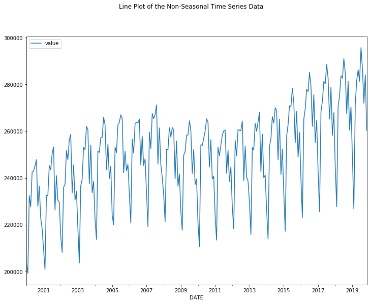

```python
# Line plots of the transformed time series
fig, ax = plt.subplots(figsize=(12,9))
fig.suptitle('Line Plot of the Non-Seasonal Time Series Data')
time_series.plot(ax=ax)
plt.show()
```

### Section 3.b) Test for Stationarity

```python
# Check if stationary
result = adfuller(time_series[target_col])
print('ADF Statistic: %f' % result[0])
print('p-value: %f' % result[1])
print('Critical Test Statistics Values:')
for key, value in result[4].items():
    print('\t%s: %.3f' % (key, value))
```

```
ADF Statistic: -0.792516
p-value: 0.821311
Critical Test Statistics Values:
	1%: -3.460
	5%: -2.875
	10%: -2.574
```

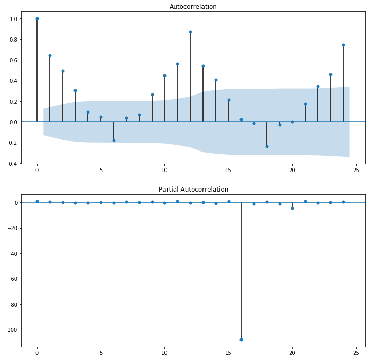

```python
# ACF and PACF plots of the time series data
fig, (ax1, ax2) = plt.subplots(2, 1, figsize=(12,12))
plot_acf(time_series, ax=ax1)
plot_pacf(time_series, ax=ax2)
plt.show()
```

### 3.c) Test for Stationarity of Non-Seasonal Time Series Data

Occasionally a time series may look non-stationary on the first look. We can make it stationary by differencing the series and using a statistical test to confirm that the differenced result is stationary. Rejecting the null hypothesis means that the process has no unit root, and in turn that the time series is stationary or does not have time-dependent structure.

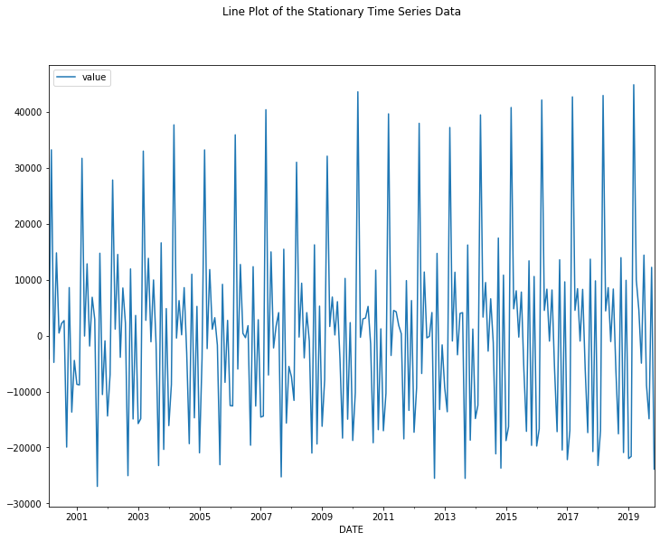

```python
# Create a differenced series
stationary_ns = time_series.diff().dropna()

# Plot differenced data
fig, ax = plt.subplots(figsize=(12,9))
fig.suptitle('Line Plot of the Stationary Time Series Data')
stationary_ns.plot(ax=ax)
plt.show()
```

```python
# Check for stationarity
result = adfuller(stationary_ns[target_col])
print('ADF Statistic: %f' % result[0])
print('p-value: %f' % result[1])
print('Critical Test Statistics Values:')
for key, value in result[4].items():
    print('\t%s: %.3f' % (key, value))
```

```
ADF Statistic: -3.520404
p-value: 0.007478
Critical Test Statistics Values:
	1%: -3.460
	5%: -2.875
	10%: -2.574
```

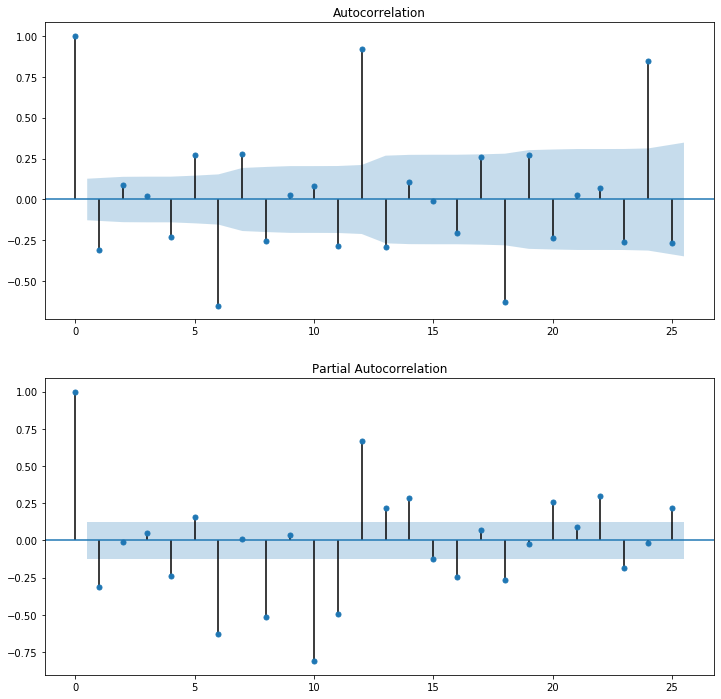

```python
# ACF and PACF plots of the stationary time series
lags = 25
fig, (ax1, ax2) = plt.subplots(2, 1, figsize=(12,12))
plot_acf(stationary_ns, lags=lags, ax=ax1)
plot_pacf(stationary_ns, lags=lags, ax=ax2)
plt.show()
```

### 3.d) Seasonal Decomposition for Seasonal Time Series Data

```python
# Set the initial seasonal frequency parameter
seasonal_freq = 12
```

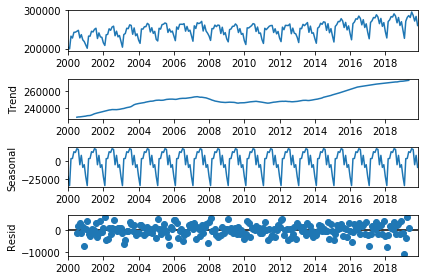

```python
# Perform seasonal decomposition to observe the seasonal frequency
decomp_results = seasonal_decompose(time_series, period=seasonal_freq)
decomp_results.plot()
plt.show()
```

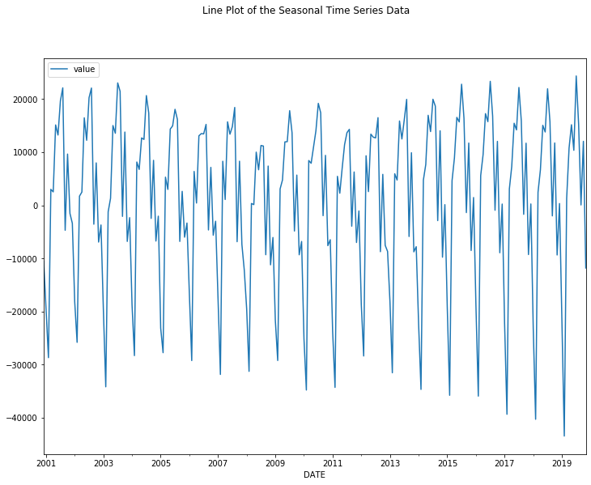

```python
# Create a seasonal series
N = seasonal_freq
seasonal_series = time_series - time_series.rolling(N).mean()
seasonal_series = seasonal_series.dropna()

# Line plots of the seasonal time series
fig, ax = plt.subplots(figsize=(12,9))
fig.suptitle('Line Plot of the Seasonal Time Series Data')
seasonal_series.plot(ax=ax)
plt.show()
```

```python
# Check for stationarity
result = adfuller(seasonal_series[target_col])
print('ADF Statistic: %f' % result[0])
print('p-value: %f' % result[1])
print('Critical Test Statistics Values:')
for key, value in result[4].items():
    print('\t%s: %.3f' % (key, value))
```

```
ADF Statistic: -2.598845
p-value: 0.093236
Critical Test Statistics Values:
	1%: -3.462
	5%: -2.875
	10%: -2.574
```

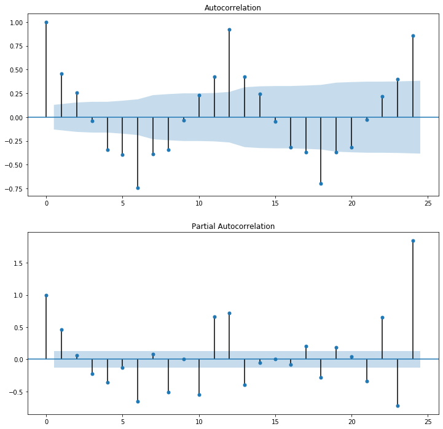

```python
# ACF and PACF plots of the time series data
lag = seasonal_freq * 2
fig, (ax1, ax2) = plt.subplots(2, 1, figsize=(12,12))
plot_acf(seasonal_series, lags=lag, ax=ax1)
plot_pacf(seasonal_series, lags=lag, ax=ax2)
plt.show()
```

### 3.e) Test for Stationarity of Seasonal Time Series Data

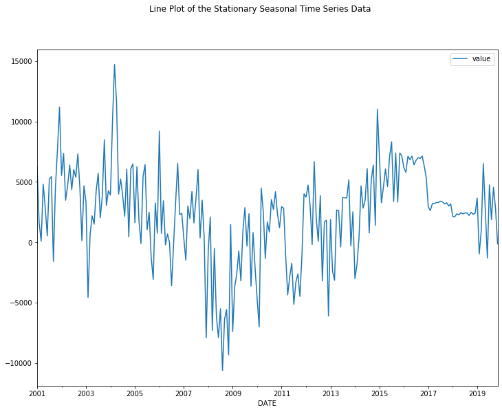

```python
# Create a differenced series
stationary_ss = time_series.diff(seasonal_freq).dropna()

# Plot differenced data
fig, ax = plt.subplots(figsize=(12,9))
fig.suptitle('Line Plot of the Stationary Seasonal Time Series Data')
stationary_ss.plot(ax=ax)
plt.show()
```

```python
# Check for stationarity
result = adfuller(stationary_ss[target_col])
print('ADF Statistic: %f' % result[0])
print('p-value: %f' % result[1])
print('Critical Test Statistics Values:')
for key, value in result[4].items():
    print('\t%s: %.3f' % (key, value))
```

```
ADF Statistic: -1.993003
p-value: 0.289649
Critical Test Statistics Values:
	1%: -3.462
	5%: -2.875
	10%: -2.574
```

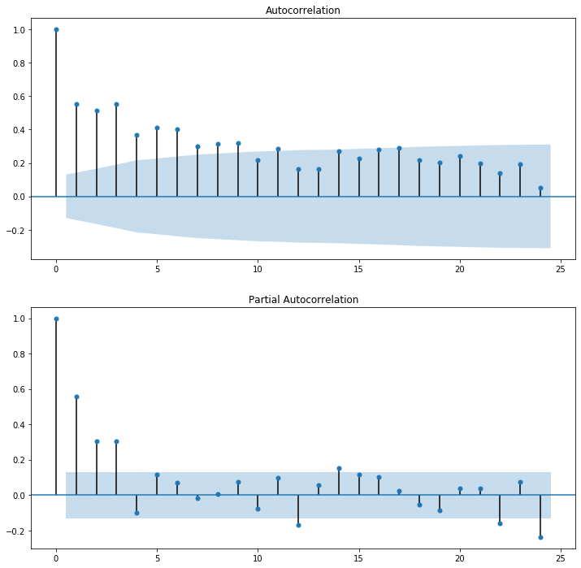

```python
# ACF and PACF plots of the stationary time series
lags = seasonal_freq * 2
fig, (ax1, ax2) = plt.subplots(2, 1, figsize=(12,12))
plot_acf(stationary_ss, lags=lags, ax=ax1)
plot_pacf(stationary_ss, lags=lags, ax=ax2)
plt.show()
```

```python
if (notifyStatus): email_notify("Data Cleaning and Pre-Processing completed! "+datetime.now().strftime('%a %B %d, %Y %I:%M:%S %p'))
```

## Section 4. Fit and Evaluate Models

In this section, we will develop Autoregressive Integrated Moving Average or ARIMA models for the problem. We will first establish a persistent model. Next we will use a grid search approach to look for an optimal ARIMA model. This will be followed by a third step of investigating the residual errors of the chosen model.

- Establish the Persistent Model
- Automatically Configure the ARIMA
- Review Residual Errors

```python
if (notifyStatus): email_notify("Model Fitting and Evaluation has begun! "+datetime.now().strftime('%a %B %d, %Y %I:%M:%S %p'))
```

### 4.a) Establish the Persistent Model

The first step before getting bogged down in data analysis and modeling is to establish a baseline of performance. This will provide both a template for evaluating models using the proposed test harness and a performance measure by which all more elaborate predictive models can be compared.

The baseline prediction for time series forecasting is called the naive forecast, or persistence. This is where the observation from the previous time step is used as the prediction for the observation at the next time step.

#### 4.a.iii) Establish the Persistent Model as Baseline

```python
# Prepare and evaluate a persistence model
X = time_series.values
X = X.astype('float32')
train_pct = 0.80
train_size = int(len(X) * train_pct)
test_size = len(X) - train_size
train_ts, test_ts = X[0:train_size], X[train_size:]

# walk-forward validation
history = [x for x in train_ts]
predictions = list()
for i in range(len(test_ts)):
    yhat = history[-1]
    predictions.append(yhat)
    obs = test_ts[i]
    history.append(obs)
    print('>Predicted=%.3f, Expected=%3.f' % (yhat, obs))

# Calculate performance
rmse = math.sqrt(mean_squared_error(test_ts, predictions))
print('RMSE for the persistent model is: %.3f' % rmse)
```

```
>Predicted=248843.000, Expected=259424
>Predicted=259424.000, Expected=239679
>Predicted=239679.000, Expected=223011
>Predicted=223011.000, Expected=265147
>Predicted=265147.000, Expected=269653
>Predicted=269653.000, Expected=277972
>Predicted=277972.000, Expected=276991
>Predicted=276991.000, Expected=285160
>Predicted=285160.000, Expected=279213
>Predicted=279213.000, Expected=262039
>Predicted=262039.000, Expected=275610
>Predicted=275610.000, Expected=255154
>Predicted=255154.000, Expected=264778
>Predicted=264778.000, Expected=242600
>Predicted=242600.000, Expected=225644
>Predicted=225644.000, Expected=268343
>Predicted=268343.000, Expected=272864
>Predicted=272864.000, Expected=281264
>Predicted=281264.000, Expected=280290
>Predicted=280290.000, Expected=288566
>Predicted=288566.000, Expected=282558
>Predicted=282558.000, Expected=265212
>Predicted=265212.000, Expected=278888
>Predicted=278888.000, Expected=258159
>Predicted=258159.000, Expected=267958
>Predicted=267958.000, Expected=244736
>Predicted=244736.000, Expected=227759
>Predicted=227759.000, Expected=270705
>Predicted=270705.000, Expected=275127
>Predicted=275127.000, Expected=283713
>Predicted=283713.000, Expected=282648
>Predicted=282648.000, Expected=290989
>Predicted=290989.000, Expected=284989
>Predicted=284989.000, Expected=267434
>Predicted=267434.000, Expected=281382
>Predicted=281382.000, Expected=260473
>Predicted=260473.000, Expected=270370
>Predicted=270370.000, Expected=248395
>Predicted=248395.000, Expected=226799
>Predicted=226799.000, Expected=271668
>Predicted=271668.000, Expected=281646
>Predicted=281646.000, Expected=286269
>Predicted=286269.000, Expected=281345
>Predicted=281345.000, Expected=295744
>Predicted=295744.000, Expected=286857
>Predicted=286857.000, Expected=271986
>Predicted=271986.000, Expected=284203
>Predicted=284203.000, Expected=260333
RMSE for the persistent model is: 18139.763
```

### 4.b) Grid Search of ARIMA Hyperparameters

We want to find a model that can do better than the persistence model on this dataset. To confirm this analysis, we can grid search a suite of ARIMA hyperparameters.

In this section, we will search values of p, d, and q for combinations (skipping those that fail to converge), and find the combination that results in the best performance. We will use a grid search to explore all combinations in a subset of integer values.

```python
if (notifyStatus): email_notify("ARIMA Hyperparameters Search has begun! "+datetime.now().strftime('%a %B %d, %Y %I:%M:%S %p'))
```

```python
# Set the initial P, D, and Q order parameters for non-seasonal ARIMA modeling
start_p = 0
start_d = None
start_q = 0
max_p = 4
max_d = 2
max_q = 4
```

```python
# Set the initial P, D, and Q order parameters for seasonal ARIMA modeling
start_P = 0
start_D = None
start_Q = 0
max_P = 2
max_D = 1
max_Q = 2
```

```python
# Testing the time series data for suggestions on the differencing term
start_d = pm.arima.ndiffs(train_ts)
print('The suggested non-seasonal differencing term is:', start_d)
if (seasonal_freq != 0):
    start_D = pm.arima.nsdiffs(train_ts, m = seasonal_freq)
    print('The suggested seasonal differencing term is:', start_D)
```

```
The suggested non-seasonal differencing term is: 1
The suggested seasonal differencing term is: 1
```

```python
print('The initial non-seasonal parameters are: p =', start_p, '| d =', start_d, '| q =', start_q)
print('The maximum non-seasonal parameters are: max_p =', max_p, '| max_d =', max_d, '| max_q =', max_q)
if (seasonal_freq != 0):
    print('The initial seasonal parameters are: P =', start_P, '| D =', start_D, '| Q =', start_Q, '| m =', seasonal_freq)
    print('The maximum seasonal parameters are: max_P =', max_P, '| max_D =', max_D, '| max_Q =', max_Q)
```

```
The initial non-seasonal parameters are: p = 0 | d = 1 | q = 0
The maximum non-seasonal parameters are: max_p = 4 | max_d = 2 | max_q = 4
The initial seasonal parameters are: P = 0 | D = 1 | Q = 0 | m = 12
The maximum seasonal parameters are: max_P = 2 | max_D = 1 | max_Q = 2
```

```python
# Do an automated stepwise search of ARIMA parameters
if (seasonal_freq == 0):
    stepwise_results = pm.auto_arima(train_ts, seasonal = False, stepwise = True, trace = True, suppress_warnings = True, random_state = seedNum)
else:
    stepwise_results = pm.auto_arima(train_ts, seasonal = True, m = seasonal_freq, stepwise = True, trace = True, suppress_warnings = True, random_state = seedNum)
```

```
Performing stepwise search to minimize aic
Fit ARIMA: (2, 1, 2)x(1, 1, 1, 12) (constant=True); AIC=3477.378, BIC=3502.832, Time=7.342 seconds
Fit ARIMA: (0, 1, 0)x(0, 1, 0, 12) (constant=True); AIC=3467.804, BIC=3474.167, Time=0.048 seconds
Fit ARIMA: (1, 1, 0)x(1, 1, 0, 12) (constant=True); AIC=3475.879, BIC=3488.606, Time=0.578 seconds
Fit ARIMA: (0, 1, 1)x(0, 1, 1, 12) (constant=True); AIC=3478.259, BIC=3490.986, Time=0.660 seconds
Fit ARIMA: (0, 1, 0)x(0, 1, 0, 12) (constant=False); AIC=3465.807, BIC=3468.988, Time=0.069 seconds
Fit ARIMA: (0, 1, 0)x(1, 1, 0, 12) (constant=True); AIC=3469.012, BIC=3478.557, Time=0.286 seconds
Fit ARIMA: (0, 1, 0)x(0, 1, 1, 12) (constant=True); AIC=3468.977, BIC=3478.522, Time=0.822 seconds
Fit ARIMA: (0, 1, 0)x(1, 1, 1, 12) (constant=True); AIC=3470.032, BIC=3482.759, Time=0.982 seconds
Fit ARIMA: (1, 1, 0)x(0, 1, 0, 12) (constant=True); AIC=3474.824, BIC=3484.369, Time=0.170 seconds
Fit ARIMA: (0, 1, 1)x(0, 1, 0, 12) (constant=True); AIC=3469.479, BIC=3479.024, Time=0.523 seconds
Fit ARIMA: (1, 1, 1)x(0, 1, 0, 12) (constant=True); AIC=3471.599, BIC=3484.326, Time=1.233 seconds
Total fit time: 12.757 seconds
```

```
                                     SARIMAX Results
==========================================================================================
Dep. Variable:                                  y   No. Observations:                  191
Model:             SARIMAX(0, 1, 0)x(0, 1, 0, 12)   Log Likelihood               -1731.903
Date:                            Tue, 17 Mar 2020   AIC                           3465.807
Time:                                    20:49:17   BIC                           3468.988
Sample:                                         0   HQIC                          3467.097
                                            - 191
Covariance Type:                              opg
==============================================================================
                 coef    std err          z      P>|z|      [0.025      0.975]
------------------------------------------------------------------------------
sigma2      1.647e+07   1.88e+06      8.737      0.000    1.28e+07    2.02e+07
===================================================================================
Ljung-Box (Q):                      167.87   Jarque-Bera (JB):                 0.80
Prob(Q):                              0.00   Prob(JB):                         0.67
Heteroskedasticity (H):               0.98   Skew:                             0.06
Prob(H) (two-sided):                  0.93   Kurtosis:                         2.70
===================================================================================

Warnings:
[1] Covariance matrix calculated using the outer product of gradients (complex-step).
```

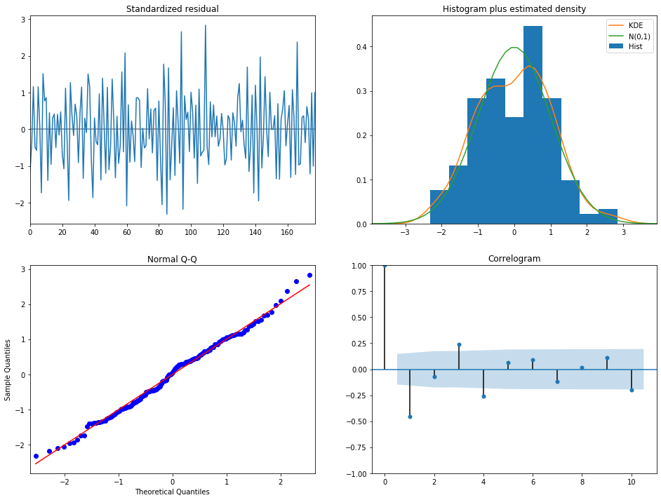

```python
# Summarize residual errors for the automated grid search ARIMA model
print(stepwise_results.summary())
stepwise_results.plot_diagnostics(figsize=(16,12))
plt.show()
```

```python
if (notifyStatus): email_notify("ARIMA automated stepwise search completed! "+datetime.now().strftime('%a %B %d, %Y %I:%M:%S %p'))
```

```python
# Do an automated random search of ARIMA parameters
n_fits = int(max_p * max_d * max_q * max_P * max_D * max_Q * 0.30)
if (seasonal_freq == 0):
    randgrid_results = pm.auto_arima(train_ts, start_p = start_p, d = start_d, start_q = start_q, max_p = max_p, max_d = max_d, max_q = max_q,
                                     seasonal = False, stepwise = False, random = True, n_fits = n_fits, max_order = None,
                                     trace = True, suppress_warnings = True, random_state = seedNum)
else:
    randgrid_results = pm.auto_arima(train_ts, start_p = start_p, d = start_d, start_q = start_q, max_p = max_p, max_d = max_d, max_q = max_q,
                                     seasonal = True, m = seasonal_freq, start_P = start_P, D = start_D, start_Q = start_Q, max_P = max_P, max_D = max_D, max_Q = max_Q,
                                     stepwise = False, random = True, n_fits = n_fits, max_order = None,
                                     trace = True, suppress_warnings = True, random_state = seedNum)
```

```
Fit ARIMA: (0, 1, 1)x(0, 1, 1, 12) (constant=True); AIC=3478.259, BIC=3490.986, Time=0.642 seconds
Fit ARIMA: (2, 1, 1)x(0, 1, 1, 12) (constant=True); AIC=3487.975, BIC=3507.066, Time=3.520 seconds
Fit ARIMA: (2, 1, 3)x(0, 1, 2, 12) (constant=True); AIC=3469.262, BIC=3497.898, Time=12.809 seconds
Fit ARIMA: (1, 1, 0)x(1, 1, 2, 12) (constant=True); AIC=3474.159, BIC=3493.250, Time=3.367 seconds
Fit ARIMA: (4, 1, 4)x(0, 1, 2, 12) (constant=True); AIC=3477.626, BIC=3515.807, Time=19.666 seconds
Fit ARIMA: (0, 1, 3)x(1, 1, 2, 12) (constant=True); AIC=3482.055, BIC=3507.509, Time=5.323 seconds
Fit ARIMA: (4, 1, 3)x(1, 1, 1, 12) (constant=True); AIC=3486.630, BIC=3521.630, Time=9.014 seconds
Fit ARIMA: (0, 1, 1)x(1, 1, 1, 12) (constant=True); AIC=3479.774, BIC=3495.683, Time=1.453 seconds
Fit ARIMA: (1, 1, 1)x(1, 1, 0, 12) (constant=True); AIC=3480.780, BIC=3496.689, Time=2.390 seconds
Fit ARIMA: (1, 1, 1)x(2, 1, 2, 12) (constant=True); AIC=3479.386, BIC=3504.841, Time=12.060 seconds
Fit ARIMA: (0, 1, 2)x(0, 1, 0, 12) (constant=True); AIC=3479.384, BIC=3492.111, Time=0.175 seconds
Fit ARIMA: (3, 1, 0)x(1, 1, 1, 12) (constant=True); AIC=3490.043, BIC=3512.315, Time=2.330 seconds
Fit ARIMA: (1, 1, 4)x(1, 1, 2, 12) (constant=True); AIC=3492.009, BIC=3523.827, Time=9.979 seconds
Fit ARIMA: (1, 1, 2)x(2, 1, 0, 12) (constant=True); AIC=3486.179, BIC=3508.451, Time=1.978 seconds
Fit ARIMA: (0, 1, 0)x(1, 1, 2, 12) (constant=True); AIC=3468.360, BIC=3484.269, Time=2.816 seconds
Fit ARIMA: (1, 1, 3)x(2, 1, 1, 12) (constant=True); AIC=3487.158, BIC=3515.794, Time=5.154 seconds
Fit ARIMA: (4, 1, 4)x(2, 1, 1, 12) (constant=True); AIC=3476.235, BIC=3517.598, Time=21.208 seconds
Fit ARIMA: (2, 1, 1)x(2, 1, 2, 12) (constant=True); AIC=3485.797, BIC=3514.433, Time=11.990 seconds
Fit ARIMA: (3, 1, 2)x(1, 1, 1, 12) (constant=True); AIC=3473.752, BIC=3502.388, Time=6.941 seconds
Fit ARIMA: (1, 1, 3)x(1, 1, 2, 12) (constant=True); AIC=3487.332, BIC=3515.968, Time=5.393 seconds
Fit ARIMA: (0, 1, 2)x(0, 1, 1, 12) (constant=True); AIC=3480.279, BIC=3496.188, Time=0.834 seconds
Fit ARIMA: (4, 1, 1)x(2, 1, 0, 12) (constant=True); AIC=3493.468, BIC=3522.104, Time=6.804 seconds
Fit ARIMA: (2, 1, 1)x(0, 1, 2, 12) (constant=True); AIC=3488.500, BIC=3510.773, Time=3.389 seconds
Fit ARIMA: (3, 1, 4)x(2, 1, 2, 12) (constant=True); AIC=3477.010, BIC=3518.373, Time=19.793 seconds
Fit ARIMA: (3, 1, 2)x(0, 1, 0, 12) (constant=True); AIC=3472.491, BIC=3494.763, Time=2.216 seconds
Fit ARIMA: (2, 1, 3)x(1, 1, 0, 12) (constant=True); AIC=3474.516, BIC=3499.970, Time=5.698 seconds
Fit ARIMA: (0, 1, 1)x(2, 1, 2, 12) (constant=True); AIC=3477.034, BIC=3499.307, Time=9.879 seconds
Fit ARIMA: (4, 1, 3)x(2, 1, 2, 12) (constant=True); AIC=3486.841, BIC=3528.204, Time=17.504 seconds
Fit ARIMA: (1, 1, 4)x(2, 1, 0, 12) (constant=True); AIC=3495.517, BIC=3524.153, Time=9.163 seconds
Fit ARIMA: (4, 1, 4)x(1, 1, 2, 12) (constant=True); AIC=3474.701, BIC=3516.064, Time=21.036 seconds
Fit ARIMA: (4, 1, 4)x(0, 1, 1, 12) (constant=True); AIC=3474.938, BIC=3509.937, Time=10.363 seconds
Fit ARIMA: (1, 1, 2)x(1, 1, 1, 12) (constant=True); AIC=3486.633, BIC=3508.905, Time=3.843 seconds
Fit ARIMA: (4, 1, 0)x(1, 1, 2, 12) (constant=True); AIC=3489.543, BIC=3518.179, Time=5.723 seconds
Fit ARIMA: (3, 1, 1)x(1, 1, 2, 12) (constant=True); AIC=3487.304, BIC=3515.941, Time=13.988 seconds
Fit ARIMA: (1, 1, 1)x(0, 1, 2, 12) (constant=True); AIC=3481.420, BIC=3500.510, Time=2.593 seconds
Fit ARIMA: (1, 1, 3)x(0, 1, 1, 12) (constant=True); AIC=3489.740, BIC=3512.012, Time=1.104 seconds
Fit ARIMA: (0, 1, 1)x(2, 1, 0, 12) (constant=True); AIC=3478.812, BIC=3494.721, Time=1.376 seconds
Fit ARIMA: (4, 1, 3)x(1, 1, 0, 12) (constant=True); AIC=3481.684, BIC=3513.501, Time=7.619 seconds
Total fit time: 281.155 seconds
```

```
                                        SARIMAX Results
===============================================================================================
Dep. Variable:                                       y   No. Observations:                  191
Model:             SARIMAX(0, 1, 0)x(1, 1, [1, 2], 12)   Log Likelihood               -1729.180
Date:                                 Tue, 17 Mar 2020   AIC                           3468.360
Time:                                         20:54:00   BIC                           3484.269
Sample:                                              0   HQIC                          3474.812
                                                 - 191
Covariance Type:                                   opg
==============================================================================
                 coef    std err          z      P>|z|      [0.025      0.975]
------------------------------------------------------------------------------
intercept      6.4533     79.870      0.081      0.936    -150.090     162.996
ar.S.L12       0.6886      0.154      4.464      0.000       0.386       0.991
ma.S.L12      -0.7266      0.161     -4.520      0.000      -1.042      -0.412
ma.S.L24      -0.0405      0.043     -0.951      0.342      -0.124       0.043
sigma2      1.655e+07   1.19e-05   1.39e+12      0.000    1.65e+07    1.65e+07
===================================================================================
Ljung-Box (Q):                      160.77   Jarque-Bera (JB):                 0.61
Prob(Q):                              0.00   Prob(JB):                         0.74
Heteroskedasticity (H):               0.90   Skew:                             0.01
Prob(H) (two-sided):                  0.68   Kurtosis:                         2.71
===================================================================================

Warnings:
[1] Covariance matrix calculated using the outer product of gradients (complex-step).
[2] Covariance matrix is singular or near-singular, with condition number 4.38e+29. Standard errors may be unstable.
```

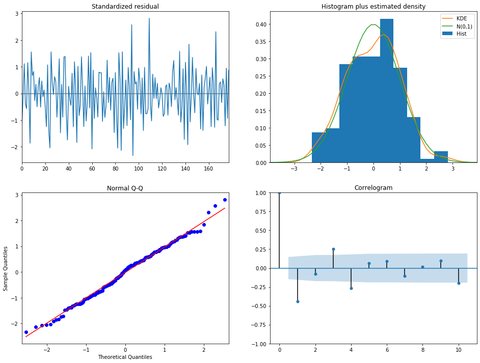

```python
# Summarize residual errors for the automated grid search ARIMA model
print(randgrid_results.summary())
randgrid_results.plot_diagnostics(figsize=(16,12))
plt.show()
```

```python
if (notifyStatus): email_notify("ARIMA automated random search completed! "+datetime.now().strftime('%a %B %d, %Y %I:%M:%S %p'))
```

```python
# Do an automated grid search of ARIMA parameters
# if (seasonal_freq == 0):
#     autogrid_results = pm.auto_arima(train_ts, start_p = start_p, d = start_d, start_q = start_q, max_p = max_p, max_d = max_d, max_q = max_q,
#                                      seasonal = False, stepwise = False, max_order = None, trace = True, suppress_warnings = True, random_state = seedNum)
# else:
#     autogrid_results = pm.auto_arima(train_ts, start_p = start_p, d = start_d, start_q = start_q, max_p = max_p, max_d = max_d, max_q = max_q,
#                                      seasonal = True, m = seasonal_freq, start_P = start_P, D = start_D, start_Q = start_Q, max_P = max_P, max_D = max_D, max_Q = max_Q,
#                                      stepwise = False, max_order = None, trace = True, suppress_warnings = True, random_state = seedNum)
```

```python
# Summarize residual errors for the automated grid search ARIMA model
# print(autogrid_results.summary())
# autogrid_results.plot_diagnostics(figsize=(12,12))
# plt.show()
```

```python
if (notifyStatus): email_notify("ARIMA automated grid search completed! "+datetime.now().strftime('%a %B %d, %Y %I:%M:%S %p'))
```

```python
# Not applicable for this iteration of the project

# Set up the function to handle the ARIMA calculation
# def Calculate_ARIMA(ns_order, ss_order):
#     startTimeModel = datetime.now()
#     aic_score, bic_score = float("inf"), float("inf")
#     if (verbose): print('Trying to fit the model with parameters:', ns_order, ss_order)
#     try:
#         if (ss_order[3] == 0): grid_model = SARIMAX(train_ts, order=ns_order)
#         else: grid_model = SARIMAX(train_ts, order=ns_order, seasonal_order=ss_order)
#         with warnings.catch_warnings():
#             warnings.simplefilter("ignore")
#             grid_results = grid_model.fit(disp = False)
#         aic_score = grid_results.aic
#         bic_score = grid_results.bic
#         if (verbose): print('Fit ARIMA: order=%s seasonal_order=%s; AIC=%.3f, BIC=%.3f, Fit time=%s' %
#               (ns_order, ss_order, aic_score, bic_score, (datetime.now() - startTimeModel)))
#         return(aic_score, bic_score)
#     except:
#         return(float("inf"), float("inf"))
```

```python
# Not applicable for this iteration of the project

# Do a manual grid search of ARIMA parameters
# best_score, best_ns_cfg, best_ss_cfg = float("inf"), None, None
# for p in range(start_p, max_p+1):
#     for d in range(start_d, max_d+1):
#         for q in range(start_q, max_q+1):
#             for P in range(start_P, max_P+1):
#                 for D in range(start_D, max_D+1):
#                     for Q in range(start_Q, max_Q+1):
#                         ns_order = (p, d, q)
#                         ss_order = (P, D, Q, seasonal_freq)
#                         aic_score, bic_score = Calculate_ARIMA(ns_order, ss_order)
#                         if (aic_score < best_score):
#                             best_ns_cfg, best_ss_cfg, best_score = ns_order, ss_order, aic_score
#                             print('A better model found: order=%s seasonal_order=%s; AIC=%.3f, BIC=%.3f' % (ns_order, ss_order, aic_score, bic_score))
# print('Best ARIMA model via manual search: order=%s seasonal_order=%s; AIC=%f' % (best_ns_cfg, best_ss_cfg, best_score))
```

```python
# Summarize residual errors for the manual ARIMA model
# manual_model = SARIMAX(train_ts, order=best_ns_cfg, seasonal_order=best_ss_cfg)
# manual_results = manual_model.fit(disp = False)
# print(manual_results.summary())
# manual_results.plot_diagnostics(figsize=(12,12))
# plt.show()
```

```python
if (notifyStatus): email_notify("ARIMA Hyperparameters Search completed! "+datetime.now().strftime('%a %B %d, %Y %I:%M:%S %p'))
```

### 4.c) Evaluate the Residual Errors

A good final check of a model is to review residual forecast errors. Ideally, the distribution of residual errors should be a Gaussian with a zero mean.

```python
# Set the ARIMA order parameters for validation and forecasting
final_ns_order = stepwise_results.order
# final_ns_order = randgrid_results.order
# final_ns_order = autogrid_results.order
# final_ns_order = best_ns_cfg
if (seasonal_freq != 0):
    final_ss_order = stepwise_results.seasonal_order
#     final_ss_order = randgrid_results.seasonal_order
#     final_ss_order = autogrid_results.seasonal_order
#     final_ss_order = best_ss_cfg
    print("Final Non-season order:", final_ns_order, 'Final Seasonal Order:', final_ss_order)
else:
    print("Final Non-season order:", final_ns_order)
```

```
Final Non-season order: (0, 1, 0) Final Seasonal Order: (0, 1, 0, 12)
```

```
                                     SARIMAX Results
==========================================================================================
Dep. Variable:                              value   No. Observations:                  239
Model:             SARIMAX(0, 1, 0)x(0, 1, 0, 12)   Log Likelihood               -2178.127
Date:                            Tue, 17 Mar 2020   AIC                           4358.253
Time:                                    20:54:02   BIC                           4361.674
Sample:                                01-01-2000   HQIC                          4359.634
                                     - 11-01-2019
Covariance Type:                              opg
==============================================================================
                 coef    std err          z      P>|z|      [0.025      0.975]
------------------------------------------------------------------------------
sigma2      1.372e+07   1.24e+06     11.062      0.000    1.13e+07    1.62e+07
===================================================================================
Ljung-Box (Q):                      196.62   Jarque-Bera (JB):                 0.65
Prob(Q):                              0.00   Prob(JB):                         0.72
Heteroskedasticity (H):               0.49   Skew:                             0.11
Prob(H) (two-sided):                  0.00   Kurtosis:                         3.16
===================================================================================

Warnings:
[1] Covariance matrix calculated using the outer product of gradients (complex-step).
```

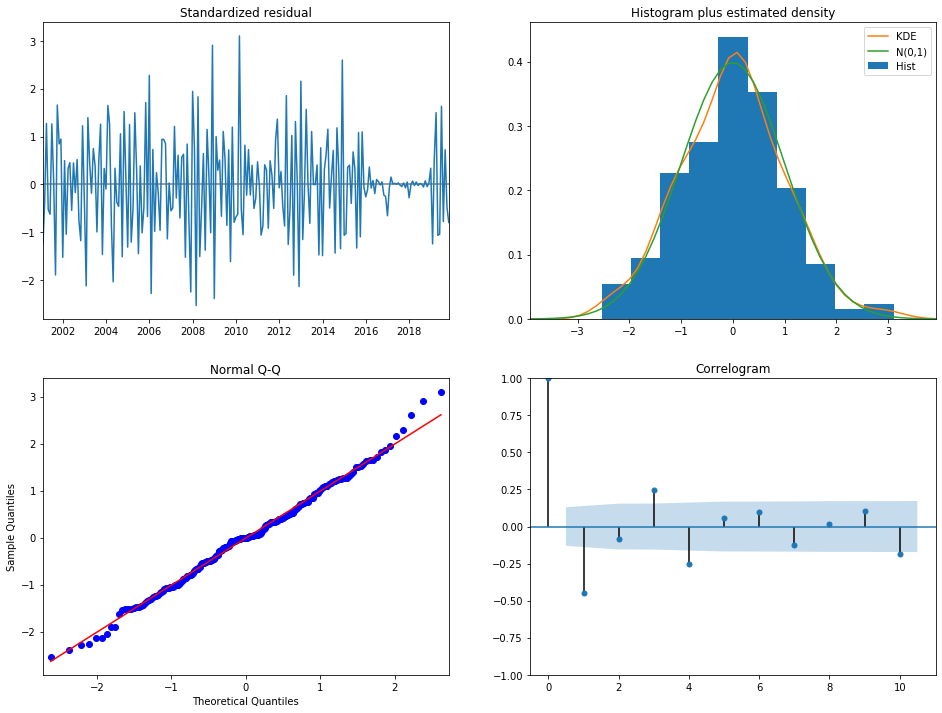

```python
# Summarize residual errors for the final ARIMA model
if (seasonal_freq != 0):
    final_model = SARIMAX(time_series, order=final_ns_order, seasonal_order=final_ss_order)
else:
    final_model = SARIMAX(time_series, order=final_ns_order)
final_results = final_model.fit(disp = False)
print(final_results.summary())
final_results.plot_diagnostics(figsize=(16,12))
plt.show()
```

```python
if (notifyStatus): email_notify("Model Fitting and Evaluation completed! "+datetime.now().strftime('%a %B %d, %Y %I:%M:%S %p'))
```

## Section 5. Finalize Model

After models have been developed and a final model selected, it must be validated and finalized. Validation is an optional part of the process, but one that provides a ‘last check’ to ensure we have not fooled or lied to ourselves.

```python
if (notifyStatus): email_notify("Model Finalization has begun! "+datetime.now().strftime('%a %B %d, %Y %I:%M:%S %p'))
```

### 5.a) Validation via In-sample Data

```python
validate_forecast = final_results.get_prediction(start = -test_size)
mean_validate_forecast = validate_forecast.predicted_mean
validate_confidence_intervals = validate_forecast.conf_int()
```

```python
# Occasionally some predicted values turned out to be < 0 but they should not be (e.g. rainfall, disease cases, etc.)
# If we have those values, we will need to set them to 0
# print(mean_validate_forecast[mean_validate_forecast < 0])
# mean_validate_forecast[mean_validate_forecast < 0] = 0
```

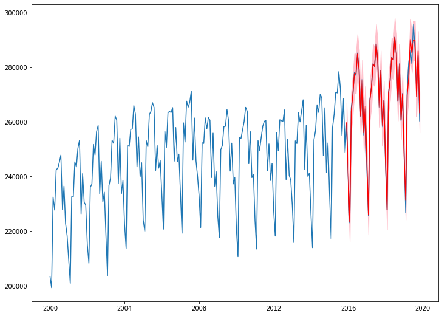

```python
plt.figure(figsize=(12,9))
plt.plot(time_series.index, time_series[target_col], label='observed')
plt.plot(mean_validate_forecast.index, mean_validate_forecast.values, color='red', label='forecast')
plt.fill_between(validate_confidence_intervals.index, validate_confidence_intervals[lower_bound],
                 validate_confidence_intervals[upper_bound], color='pink')
plt.show()
```

```python
# Evaluate RMSE for the validation data
y_test = time_series[-test_size:]
predictions = mean_validate_forecast.values
for i in range(y_test.shape[0]):
    print(y_test.index[i], ' | ', y_test.iloc[i,0], ' | ', predictions[i])
print('RMSE from the validation data is: %.3f' % math.sqrt(mean_squared_error(y_test, predictions)))
```

```
2015-12-01 00:00:00  |  259424  |  259663.0
2016-01-01 00:00:00  |  239679  |  240651.0
2016-02-01 00:00:00  |  223011  |  223401.0
2016-03-01 00:00:00  |  265147  |  263808.0
2016-04-01 00:00:00  |  269653  |  269947.0
2016-05-01 00:00:00  |  277972  |  277675.0
2016-06-01 00:00:00  |  276991  |  277707.0
2016-07-01 00:00:00  |  285160  |  284789.0
2016-08-01 00:00:00  |  279213  |  278997.0
2016-09-01 00:00:00  |  262039  |  262094.0
2016-10-01 00:00:00  |  275610  |  275418.0
2016-11-01 00:00:00  |  255154  |  255984.0
2016-12-01 00:00:00  |  264778  |  265735.0
2017-01-01 00:00:00  |  242600  |  245033.0
2017-02-01 00:00:00  |  225644  |  225932.0
2017-03-01 00:00:00  |  268343  |  267780.0
2017-04-01 00:00:00  |  272864  |  272849.0
2017-05-01 00:00:00  |  281264  |  281183.0
2017-06-01 00:00:00  |  280290  |  280283.0
2017-07-01 00:00:00  |  288566  |  288459.0
2017-08-01 00:00:00  |  282558  |  282619.0
2017-09-01 00:00:00  |  265212  |  265384.0
2017-10-01 00:00:00  |  278888  |  278783.0
2017-11-01 00:00:00  |  258159  |  258432.0
2017-12-01 00:00:00  |  267958  |  267783.0
2018-01-01 00:00:00  |  244736  |  245780.0
2018-02-01 00:00:00  |  227759  |  227780.0
2018-03-01 00:00:00  |  270705  |  270458.0
2018-04-01 00:00:00  |  275127  |  275226.0
2018-05-01 00:00:00  |  283713  |  283527.0
2018-06-01 00:00:00  |  282648  |  282739.0
2018-07-01 00:00:00  |  290989  |  290924.0
2018-08-01 00:00:00  |  284989  |  284981.0
2018-09-01 00:00:00  |  267434  |  267643.0
2018-10-01 00:00:00  |  281382  |  281110.0
2018-11-01 00:00:00  |  260473  |  260653.0
2018-12-01 00:00:00  |  270370  |  270272.0
2019-01-01 00:00:00  |  248395  |  247148.0
2019-02-01 00:00:00  |  226799  |  231418.0
2019-03-01 00:00:00  |  271668  |  269745.0
2019-04-01 00:00:00  |  281646  |  276090.0
2019-05-01 00:00:00  |  286269  |  290232.0
2019-06-01 00:00:00  |  281345  |  285204.0
2019-07-01 00:00:00  |  295744  |  289686.0
2019-08-01 00:00:00  |  286857  |  289744.0
2019-09-01 00:00:00  |  271986  |  269302.0
2019-10-01 00:00:00  |  284203  |  285934.0
2019-11-01 00:00:00  |  260333  |  263294.0
RMSE from the validation data is: 1856.154
```

### 5.b) Forecasting Out-of-Sample Data

```python
if (seasonal_freq != 0):
    forecast_size = seasonal_freq
else:
    forecast_size = 1
final_forecast = final_results.get_forecast(steps = forecast_size)
mean_final_forecast = final_forecast.predicted_mean
final_confidence_intervals = final_forecast.conf_int()
print("The forecasted values are:\n\n", mean_final_forecast)
```

```
The forecasted values are:

 2019-12-01    270230.0
2020-01-01    248255.0
2020-02-01    226659.0
2020-03-01    271528.0
2020-04-01    281506.0
2020-05-01    286129.0
2020-06-01    281205.0
2020-07-01    295604.0
2020-08-01    286717.0
2020-09-01    271846.0
2020-10-01    284063.0
2020-11-01    260193.0
Freq: MS, dtype: float64
```

```python
# Occasionally some predicted values turned out to be < 0 but they should not be (e.g. rainfall, disease cases, etc.)
# If we have those values, we will need to set them to 0
# print(mean_final_forecast[mean_final_forecast < 0])
# mean_final_forecast[mean_final_forecast < 0] = 0
```

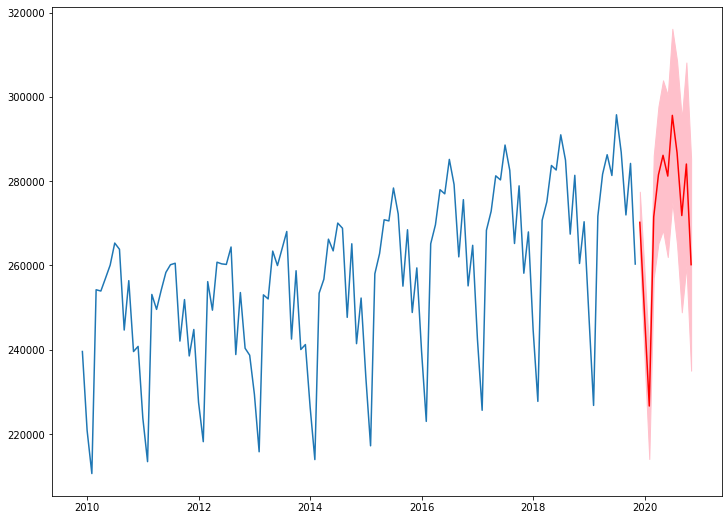

```python
plt.figure(figsize=(12,9))
halfway_point = int(time_series.index.size / 2)
plt.plot(time_series.index[halfway_point:], time_series[target_col][halfway_point:], label='observed')
plt.plot(mean_final_forecast.index, mean_final_forecast.values, color='red', label='forecast')
plt.fill_between(final_confidence_intervals.index, final_confidence_intervals[lower_bound],
                 final_confidence_intervals[upper_bound], color='pink')
plt.show()
```

```python
if (notifyStatus): email_notify("Model Finalization completed! "+datetime.now().strftime('%a %B %d, %Y %I:%M:%S %p'))
```

```python
print ('Total time for the script:',(datetime.now() - startTimeScript))
```

```
Total time for the script: 0:05:14.469288
```